# Nitrous Acid Program in R (NAPR)

Bode Hoover

2023-05-22

## About me

- Implementation of the Nitrous Acid Program in R (NAPR) for standardized form of calculating HONO sources and modeling [HONO]
- Currently only working for diurnal.
- Easily use diurnals package if needed (https://github.com/bhoover59/diurnals)
- Later will make RShiny App for best UI

### Clear memory

```r
rm(list = ls())
```

### Get input file and functions

- Getting functions from other scripts
- OR put app.R shiny app in same folder!
- **Input concentrations must be ppb**
- You might have to adjust the working directory if functions don’t load. They are in NAPR/R/file.R

```r
path <- getwd()
file <- paste(path, '/get_functions', '.R', sep = "")
source(file)
get_functions() # load files to enable functions
```

### Get input data csv

```r
df <- get_input_file() # Load csv file. INPUT IN PPB FOR SPECIES
```

### Dependencies

Install and load necessary packages

```r
load_packages()
```

### Check input

They don’t have to have valid data, but they must exist

```r
check_input(df)
```

```
## [1] "Congrats, all of the columns needed are here!"
```

### Initial parameters

Includes constants and user options Convert units to molec/cm3 from ppb

```r
initial <- get_initial()
df <- convert_to_percc(df)
```

### Optional functions

Must have Rain column for filtering * Compare options: * Rain only = 1 * Dry only = 0 * All data otherwise

```r
df <- get_rain_days(df = df, compare = 0)
```

### Meteorological information

RH input must be % right now. Might update to have optional conversion Pressure must be in atm. Might update to have optional conversion

```r
df <- get_met(df = df, temp_units = 'C', temp_column = 'Temp')
```

### Photolysis and TUV Model

TUV model takes a couple of minutes to run * NCAR TUV differs substantially from MCM & F0AM * FIX JHONO SO IT WORKS CONSISTENTLY * Sometimes TUV output is weird, especially on fringes so you may need to edit some values especially if 0 –> infinity * JNO2 = 1, use JNO2 measurements * JNO2 = 2 use TUV modeled JNO2 * Jcorr = 1 calculate Jcorr by JNO2 measured/JNO2 TUV * Jcorr = 0 input your own column of Jcorr values * Jcorr = 2 input JHONO values * Jcorr = else use ideal conditions (don’t want to scale by Jcorr), not recommended * Calculates JHONO based on JNO2 and Jcorr

```r
df <- TUV_hourly(df = df, date = 20220728, latitude = 45.568100, longitude = -84.682869, gAltitude = 0.2667, mAltitude = 0.26715)
df <- get_J_values(df = df, JNO2 = 1, Jcorr = 1)
```

### Run the model

```r
df_kinetics <- get_kinetics(df, initial) # get rate constants and boundary layer height
df_model <- run_model(df_kinetics, initial) # calculate HONO and unknown source
```

### Plotting

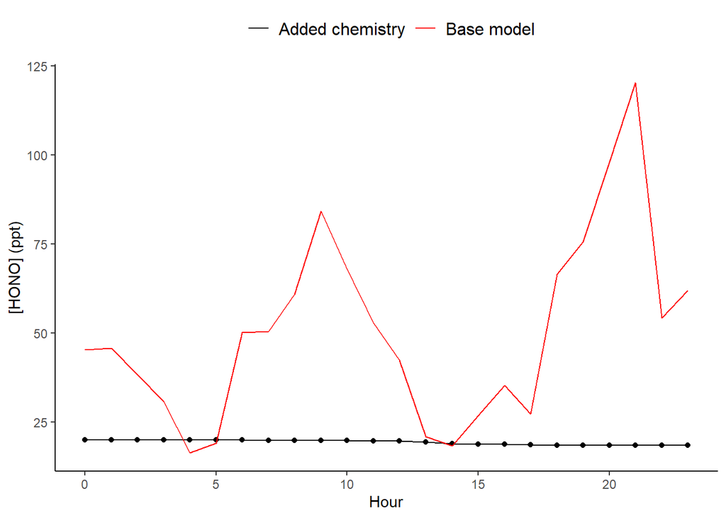

```r
plot_HONO(df = df_model, xlab = 'Hour', ylab = '[HONO] (ppt)')
```

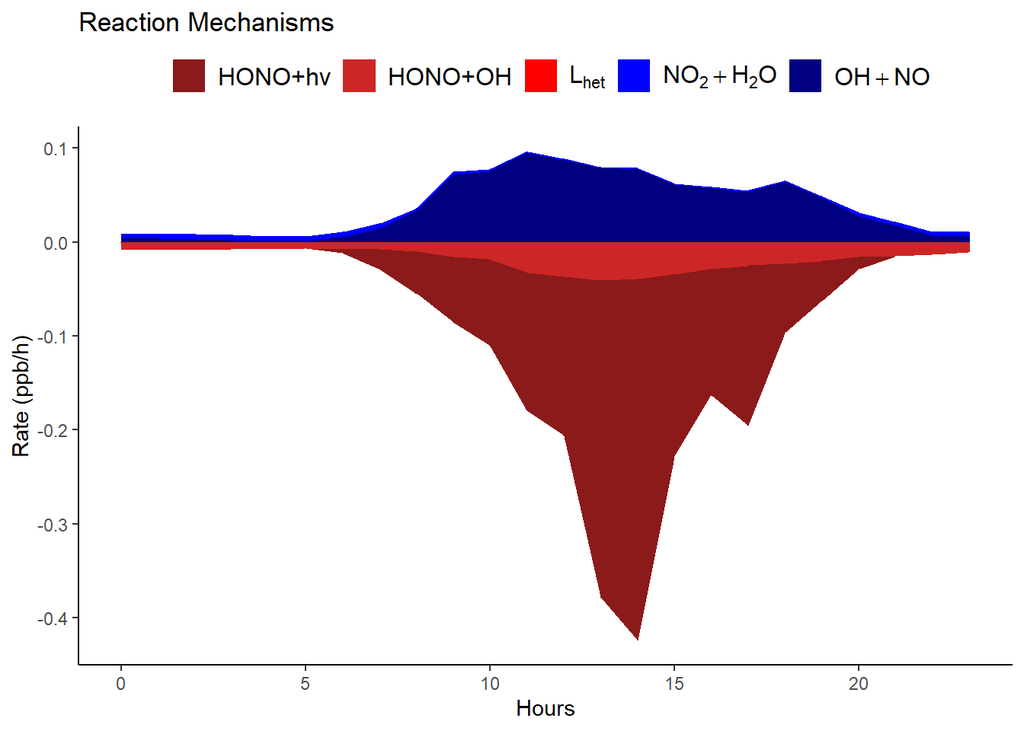

```r
# plot_HONO_model_comparison(df = df_model) # compare base and added chemistry
# plot_species(df = df_model, species = 'diff', xlab = 'Hour', ylab = 'J Photolysis (s-)')
# plot_stacked_rates(df = df_model) # plot stacked loss rates with total production line
# plot_all_stacked_rates(df = df_model) # plot all individual production and loss rates stacked
plot_rates(df = df_model) # plot all individual production and loss rates stacked
```

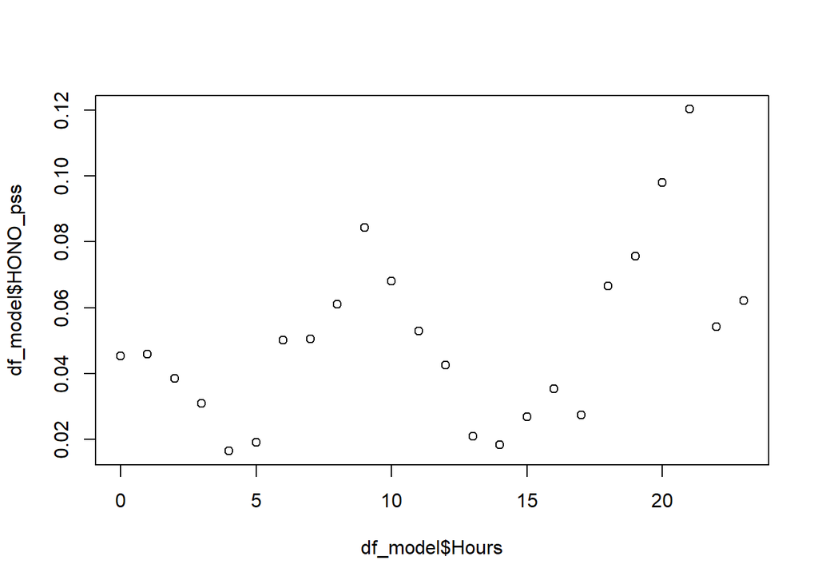

```r
plot(df_model$Hours, df_model$HONO_pss) # Plot base model
```

### Summary report

```r
report_summary(df_model)
```

```
##            vars  n        mean          sd      median     trimmed         mad
## unknown       1 24 -2560240.94 21223703.70 -7577341.26 -3723650.38 23181869.47
## HONO_pss      2 24        0.05        0.03        0.05        0.05        0.03
## HONO_model    3 24       19.38        0.63       19.74       19.40        0.38
##                     min         max       range  skew kurtosis         se
## unknown    -30722890.80 41928166.20 72651057.00  0.51    -0.94 4332270.38
## HONO_pss           0.02        0.12        0.10  0.81     0.18       0.01
## HONO_model        18.56       20.00        1.44 -0.29    -1.85       0.13
```

### Output csv

```r
output_csv(df_model, file_name = 'NAPR output') # output csv to working directory
```